# Variable glossary — correlates of success analyses

## 6 Investigating likely codependencies

This section empirically tests relationships between variables that are likely to be redundant. For each group, a correlation matrix is shown and a recommendation made for which variable to retain.

### 6.1 num_changes_loop vs loop1_len

**Question:** Is `num_changes_loop` an independent measure of how much the designed sequence diverges from native, or is it simply a proxy for loop length?

ProteinMPNN rarely reproduces native residue identities in the design region because the RFDiffusion-generated backbone has different local geometry from the native protein — MPNN optimises for the new backbone rather than recovering the original sequence context. If sequence recovery is near-zero for all designs regardless of loop length, then `num_changes_loop` carries no information beyond the loop length itself.

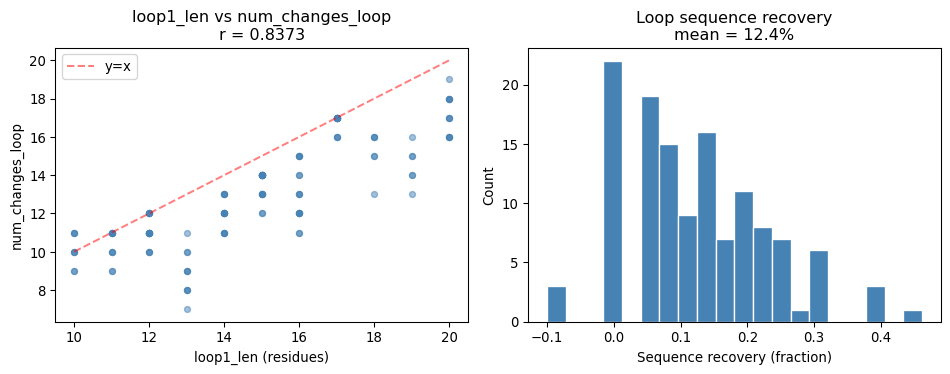

```
Correlation: r = 0.8373
Mean sequence recovery: 12.4%
Max sequence recovery: 46.2%
```

```python
seq_recovery = (1 - df["num_changes_loop"] / df["loop1_len"]).mean() * 100
r_loop = np.corrcoef(df["loop1_len"], df["num_changes_loop"])[0, 1]

import matplotlib.pyplot as plt
fig, axes = plt.subplots(1, 2, figsize=(10, 4))

axes[0].scatter(df["loop1_len"], df["num_changes_loop"], alpha=0.5, s=20, color="steelblue")
axes[0].set_xlabel("loop1_len (residues)")
axes[0].set_ylabel("num_changes_loop")
axes[0].set_title(f"loop1_len vs num_changes_loop\nr = {r_loop:.4f}")
axes[0].plot([df.loop1_len.min(), df.loop1_len.max()],
             [df.loop1_len.min(), df.loop1_len.max()], 'r--', alpha=0.5, label="y=x")
axes[0].legend()

axes[1].hist(1 - df["num_changes_loop"] / df["loop1_len"], bins=20,
             color="steelblue", edgecolor="white")
axes[1].set_xlabel("Sequence recovery (fraction)")
axes[1].set_ylabel("Count")
axes[1].set_title(f"Loop sequence recovery\nmean = {seq_recovery:.1f}%")
plt.tight_layout()
plt.show()

print(f"Correlation: r = {r_loop:.4f}")
print(f"Mean sequence recovery: {seq_recovery:.1f}%")
print(f"Max sequence recovery: {(1 - df.num_changes_loop / df.loop1_len).max()*100:.1f}%")
```

### 6.2 Rosetta metric redundancies

**Question:** Which Rosetta metrics carry independent information, and which are redundant?

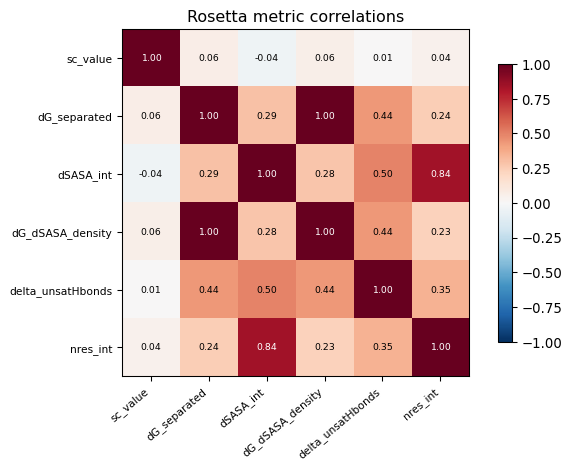

```python
r_cols = ["sc_value","dG_separated","dSASA_int","dG_dSASA_density",
          "delta_unsatHbonds","nres_int"]
r_corr = rf[r_cols].apply(pd.to_numeric, errors="coerce").corr().round(3)

fig, ax = plt.subplots(figsize=(7, 5))
im = ax.imshow(r_corr.values, cmap="RdBu_r", vmin=-1, vmax=1)
ax.set_xticks(range(len(r_cols))); ax.set_xticklabels(r_cols, rotation=40, ha="right", fontsize=8)
ax.set_yticks(range(len(r_cols))); ax.set_yticklabels(r_cols, fontsize=8)
for i in range(len(r_cols)):
    for j in range(len(r_cols)):
        v = r_corr.values[i, j]
        if not np.isnan(v):
            ax.text(j, i, f"{v:.2f}", ha="center", va="center", fontsize=7,
                    color="white" if abs(v) > 0.7 else "black")
plt.colorbar(im, ax=ax, shrink=0.8)
ax.set_title("Rosetta metric correlations")
plt.tight_layout()
plt.show()
```

**Findings:**

- `dG_separated_win` and `dG_dSASA_density`: r = 0.999 — exclude one. `dG_separated_win` is retained as the more interpretable raw quantity.
- `dSASA_int` and `nres_int`: r = 0.842 — highly correlated. Retain `dSASA_int` as the continuous measure; exclude the count `nres_int`.
- `sc_value`: |r| < 0.10 with all other Rosetta metrics — entirely independent signal. Retain.
- `delta_unsatHbonds`: moderate correlations with `dSASA_int` (0.498) and `dG_separated_win` (0.436). Partially independent, but computed on non-native rotamers; treat as uncertain.

**Recommendation:** Retain `sc_value`, `dSASA_int`. Retain `delta_unsatHbonds` tentatively. Exclude `dG_dSASA_density`, `nres_int`, `packstat`.

### 6.3 Boltz confidence metric redundancies

**Question:** Among the Boltz confidence metrics, which carry independent information?

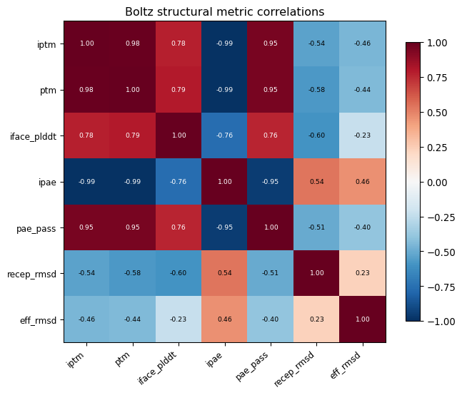

```python
b_cols = ["rep_iptm_median","rep_ptm_median","rep_interface_plddt_median",
          "rep_ipae_median","rep_pae_pass_frac_median",
          "rep_independent_receptor_rmsd_median","rep_independent_effector_rmsd_median"]
b_corr = df[b_cols].apply(pd.to_numeric, errors="coerce").corr().round(3)
short = ["iptm","ptm","iface_plddt","ipae","pae_pass","recep_rmsd","eff_rmsd"]

fig, ax = plt.subplots(figsize=(7, 6))
im = ax.imshow(b_corr.values, cmap="RdBu_r", vmin=-1, vmax=1)
ax.set_xticks(range(len(short))); ax.set_xticklabels(short, rotation=40, ha="right", fontsize=9)
ax.set_yticks(range(len(short))); ax.set_yticklabels(short, fontsize=9)
for i in range(len(short)):
    for j in range(len(short)):
        v = b_corr.values[i, j]
        if not np.isnan(v):
            ax.text(j, i, f"{v:.2f}", ha="center", va="center", fontsize=7,
                    color="white" if abs(v) > 0.7 else "black")
plt.colorbar(im, ax=ax, shrink=0.8)
ax.set_title("Boltz structural metric correlations")
plt.tight_layout()
plt.show()
```

**Findings:**

- `iptm`, `ptm`, `ipae`, `pae_pass_frac` form a tight cluster: |r| > 0.94 between all pairs. They all measure global complex confidence from the same PAE/pTM outputs — retain `iptm` only as the most interpretable.
- `interface_plddt`: r = 0.779 with iptm — correlated but not redundant. It captures per-residue confidence specifically at the contact surface, which is a distinct aspect from global chain-orientation confidence. Retain.
- `receptor_rmsd` and `effector_rmsd`: r = 0.234 with each other — largely independent. Both retained.

**Recommendation:** Retain `iptm`, `interface_plddt`, `receptor_rmsd`, `effector_rmsd`. Exclude `ptm`, `ipae`, `pae_pass_frac`.

### 6.4 MPNN score redundancies

**Question:** Do `mpnn_score`, `design_region_score`, and `mpnn_dr_ratio` each carry independent information?

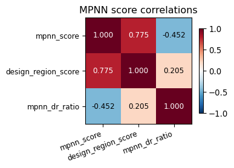

```python
m_cols = ["mpnn_score","design_region_score","mpnn_dr_ratio"]
m_corr = df[m_cols].apply(pd.to_numeric, errors="coerce").corr().round(3)

fig, ax = plt.subplots(figsize=(4, 3))
im = ax.imshow(m_corr.values, cmap="RdBu_r", vmin=-1, vmax=1)
ax.set_xticks([0,1,2]); ax.set_xticklabels(m_cols, rotation=20, ha="right", fontsize=9)
ax.set_yticks([0,1,2]); ax.set_yticklabels(m_cols, fontsize=9)
for i in range(3):
    for j in range(3):
        ax.text(j, i, f"{m_corr.values[i,j]:.3f}", ha="center", va="center",
                fontsize=9, color="white" if abs(m_corr.values[i,j]) > 0.7 else "black")
plt.colorbar(im, ax=ax, shrink=0.8)
ax.set_title("MPNN score correlations")
plt.tight_layout()
plt.show()
```

**Findings:**

**Recommendation:** Retain `mpnn_score` and `design_region_score`. Exclude `mpnn_dr_ratio` — it is derived from the other two and does not add independent information.

### 6.5 Contact metric entanglement with composite score

**Question:** Is `rep_wrong_jaccard_median` sufficiently independent of the composite score to be used as a predictor of hit outcome?

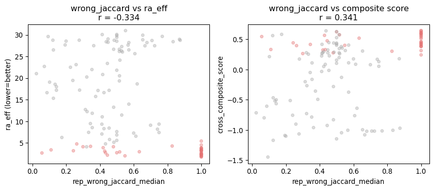

```
r(wrong_jaccard, ra_eff) = -0.334
r(wrong_jaccard, composite_score) = 0.341
```

```python
wj = pd.to_numeric(df["rep_wrong_jaccard_median"], errors="coerce")
ra = pd.to_numeric(df["rep_ra_eff_vs_truth_median"], errors="coerce")
cs = pd.to_numeric(df["cross_composite_score"], errors="coerce")

mask1 = wj.notna() & ra.notna()
mask2 = wj.notna() & cs.notna()
r_ra  = np.corrcoef(wj[mask1], ra[mask1])[0, 1]
r_cs  = np.corrcoef(wj[mask2], cs[mask2])[0, 1]

import matplotlib.pyplot as plt
fig, axes = plt.subplots(1, 2, figsize=(9, 4))
for ax, y, ylabel, r, title in [
    (axes[0], ra[mask1], "ra_eff (lower=better)", r_ra,
     f"wrong_jaccard vs ra_eff\nr = {r_ra:.3f}"),
    (axes[1], cs[mask2], "cross_composite_score", r_cs,
     f"wrong_jaccard vs composite score\nr = {r_cs:.3f}"),
]:
    ax.scatter(wj[y.index], y, alpha=0.4, s=18,
               c=df.loc[y.index, "hit"].map({0: "#aaa", 1: "#E57373"}))
    ax.set_xlabel("rep_wrong_jaccard_median")
    ax.set_ylabel(ylabel)
    ax.set_title(title)
plt.tight_layout()
plt.show()

print(f"r(wrong_jaccard, ra_eff) = {r_ra:.3f}")
print(f"r(wrong_jaccard, composite_score) = {r_cs:.3f}")
```

## 7 Final recommended feature set

```python
final = pd.DataFrame([
    dict(feature="sc_value",                       stage="Rosetta", rationale="Independent backbone geometry metric"),
    dict(feature="dSASA_int",                      stage="Rosetta", rationale="Buried interface area; backbone-meaningful"),
    dict(feature="delta_unsatHbonds",              stage="Rosetta", rationale="Tentative: sidechain-dependent but partially independent"),
    dict(feature="loop1_len",                      stage="Rosetta", rationale="RFDiffusion loop length decision"),
    dict(feature="mpnn_score",                     stage="MPNN",    rationale="Global sequence designability"),
    dict(feature="design_region_score",            stage="MPNN",    rationale="De novo region designability"),
    dict(feature="loop_hydrophob_frac",            stage="MPNN",    rationale="Loop composition — actionable"),
    dict(feature="loop_net_charge",                stage="MPNN",    rationale="Loop composition — actionable"),
    dict(feature="loop_has_proline",               stage="MPNN",    rationale="Loop composition — actionable"),
    dict(feature="rep_iptm_median",                stage="Boltz",   rationale="Representative of global confidence cluster"),
    dict(feature="rep_interface_plddt_median",     stage="Boltz",   rationale="Interface-specific confidence; distinct from iptm"),
    dict(feature="rep_independent_receptor_rmsd",  stage="Boltz",   rationale="Receptor misfolding in complex"),
    dict(feature="rep_independent_effector_rmsd",  stage="Boltz",   rationale="Binder misfolding in complex"),
    dict(feature="rep_n_contact_residues_median",  stage="Contact", rationale="Total interface size from Boltz"),
])
display(final.style.hide(axis="index")
        .set_properties(**{"background-color":"#e8f5e9","text-align":"left"})
        .set_table_styles([{"selector":"th","props":[("text-align","left")]}]))
```

| feature | stage | rationale |
| --- | --- | --- |
| sc_value | Rosetta | Independent backbone geometry metric |
| dSASA_int | Rosetta | Buried interface area; backbone-meaningful |
| delta_unsatHbonds | Rosetta | Tentative: sidechain-dependent but partially independent |
| loop1_len | Rosetta | RFDiffusion loop length decision |
| mpnn_score | MPNN | Global sequence designability |
| design_region_score | MPNN | De novo region designability |
| loop_hydrophob_frac | MPNN | Loop composition — actionable |
| loop_net_charge | MPNN | Loop composition — actionable |
| loop_has_proline | MPNN | Loop composition — actionable |
| rep_iptm_median | Boltz | Representative of global confidence cluster |
| rep_interface_plddt_median | Boltz | Interface-specific confidence; distinct from iptm |
| rep_independent_receptor_rmsd | Boltz | Receptor misfolding in complex |
| rep_independent_effector_rmsd | Boltz | Binder misfolding in complex |
| rep_n_contact_residues_median | Contact | Total interface size from Boltz |